# Tarea 4

12/13/2021

Para comenzar, lo primero que hay que hacer es instalar los paquetes de tidyverse, paletteer, y bases de dato para poder realizar el ejercicio. En este caso, como ejemplo, tomaremos palmerpenguins y chilemapas.

Con esta información cargada, crearemos dos gráficos, uno de barras y otro de puntos, con los datos anteriores, para poder modificarlos más adelante:

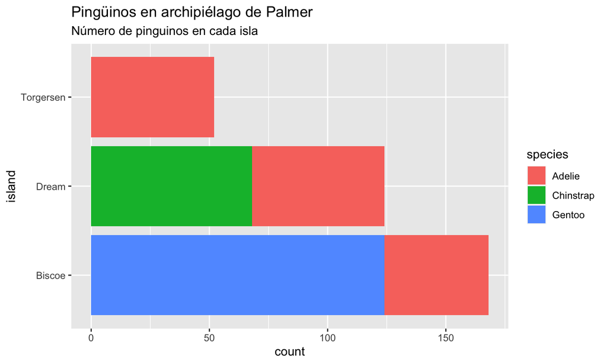

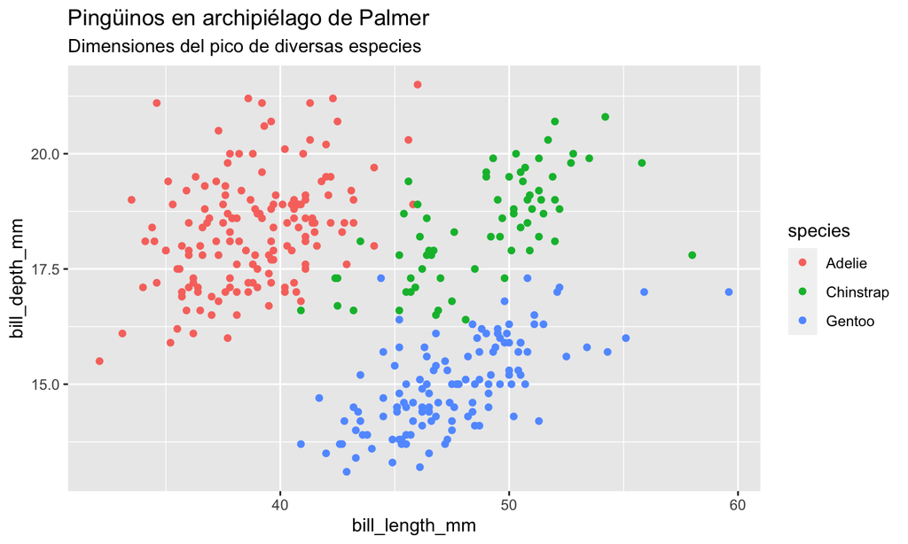

Ahora, a dejar volar la imaginación y crear una paleta de colores propias. Para esto utilizaremos paletteeer y el sitio web https://emilhvitfeldt.github.io/r-color-palettes/discrete.html nos ayudará para buscar paletas de colores ya hechas.

```
## <colors>
## #171C45FF #3E2361FF #622E82FF #A45789FF #8EC87AFF #439E5FFF
```

```
## <colors>
## #01213DFF #022A44FF #1D96BFFF #985F81FF #9B3257FF #480F1FFF
```

Ya tenemos diferentes códigos de colores. Podemos seleccionar los que más nos gusten y diseñar nuestra propia paleta de colores.

Con nuestra paleta ya diseñada, podemos utilizarlas para los gráficos que hicimos anteriormente.

Primer ejemplo

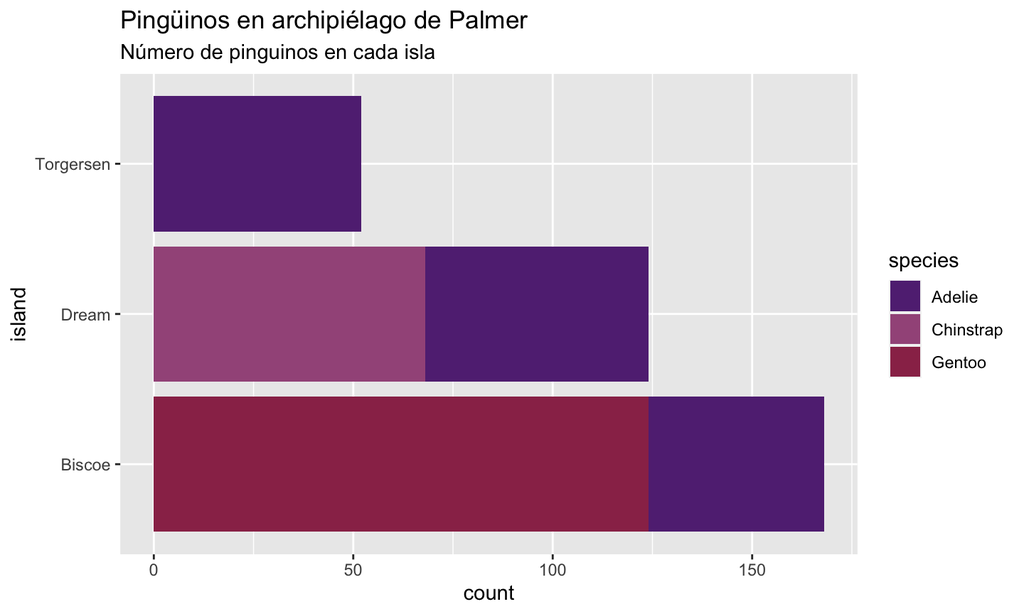

Segundo ejemplo

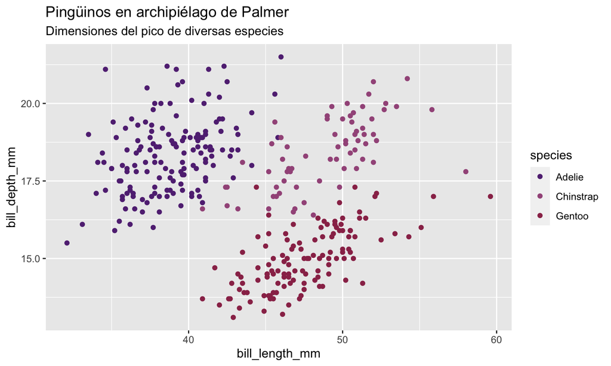

Con el mismo método anterior, creamos lo que se conoce como una paleta discreta. Haremos dos: una para el aesthetic “fill” y otra para “color”. Se puede seleccionar cualquier color que sea de nuestro agrado.

```
## <colors>
## #D56702FF #EA8425FF #FCCD1BFF #EFE3D7FF #EFEFEFFF #DB1C6AFF
```

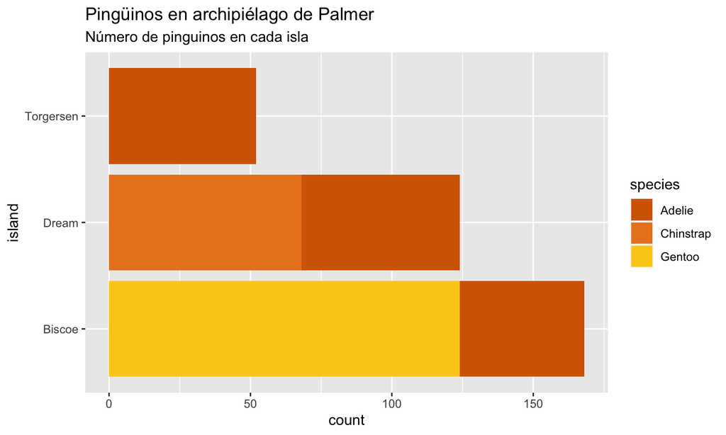

```
## <colors>
## #D56702FF #EA8425FF #FCCD1BFF #EFE3D7FF #EFEFEFFF #DB1C6AFF
```

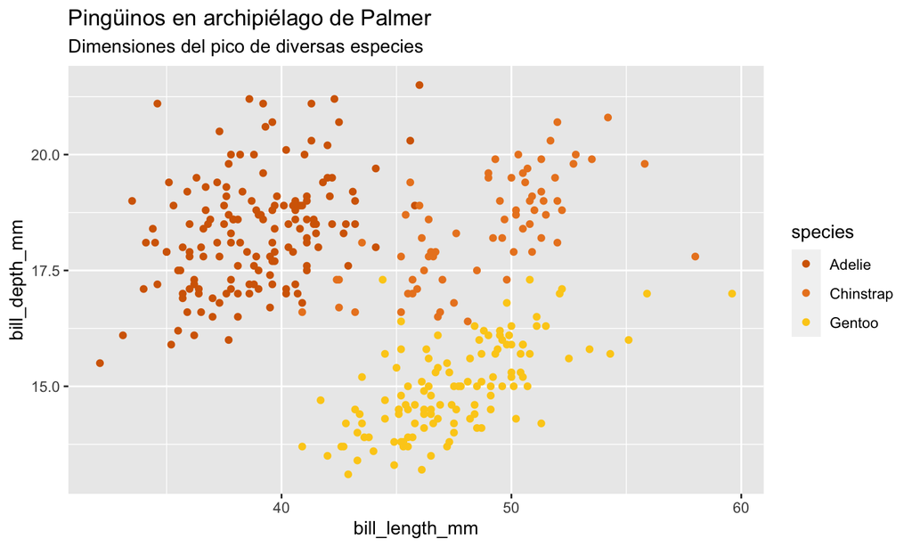

Usando la información de este sitio https://ggplot2.tidyverse.org/articles/articles/faq-customising.html, cambiaremos el tamaño de la letra y del subtítulo de tus gráficos.

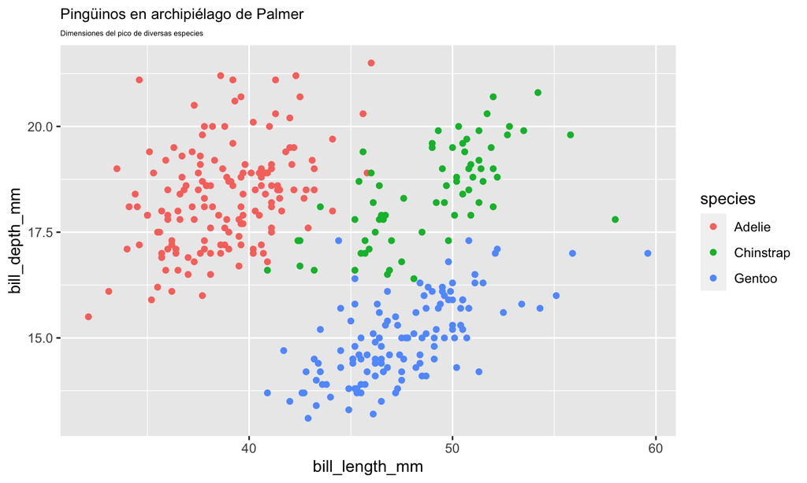

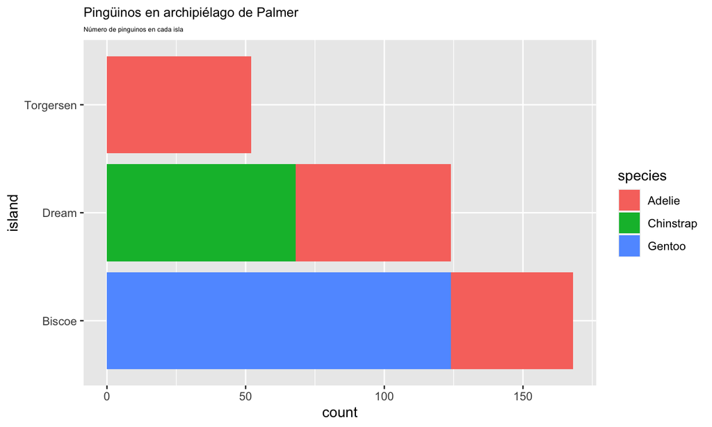

A continuación, y con la misma información, cambiaremos el color tanto del título como el subtítulo, manteniendo los nuevos tamaños de las letras.

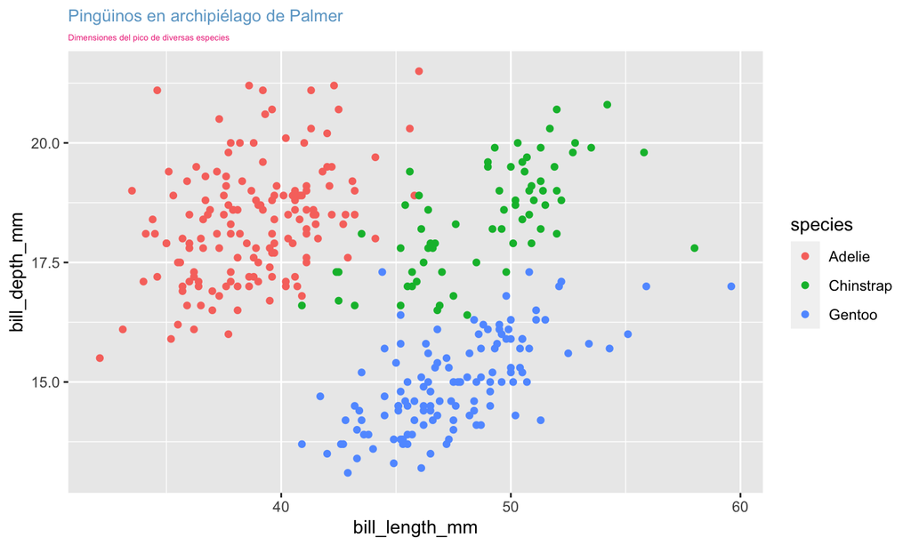

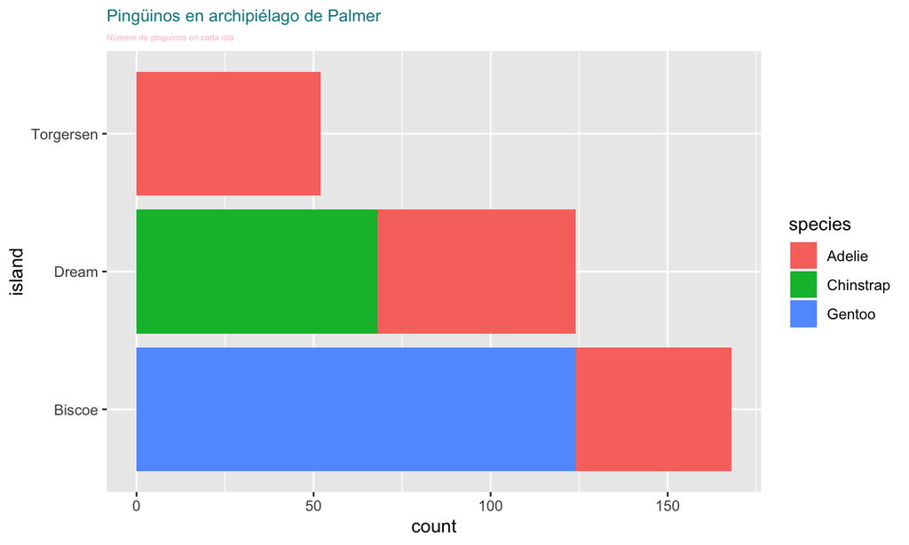

Utilizando la información de https://ggplot2-book.org/polishing.html, eliminaremos el color del background del gráfico; y luego eliminaremos las grillas mayores y menores. Mantendremos los cambios realizados anteriormente.

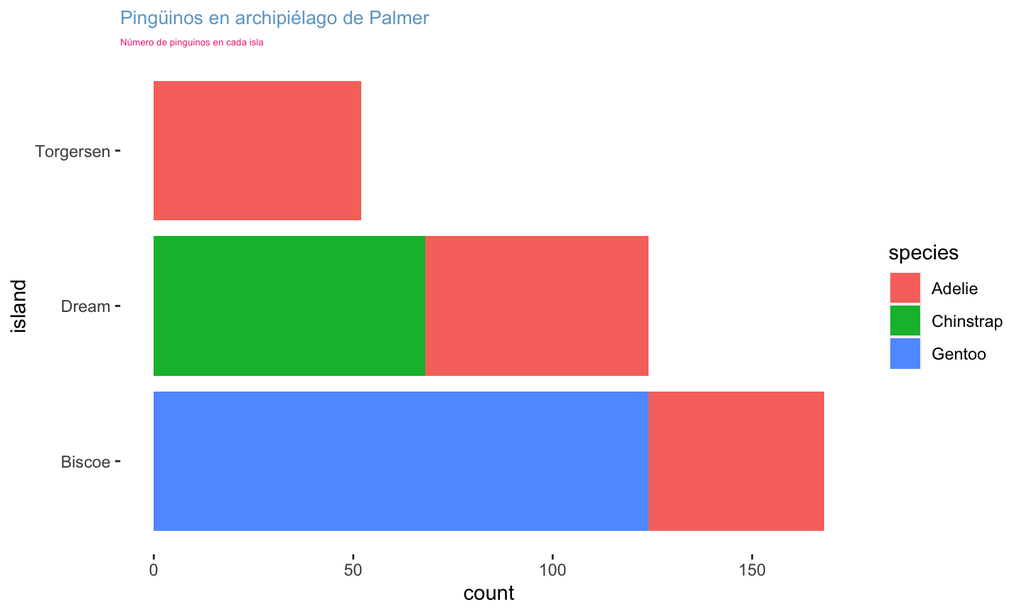

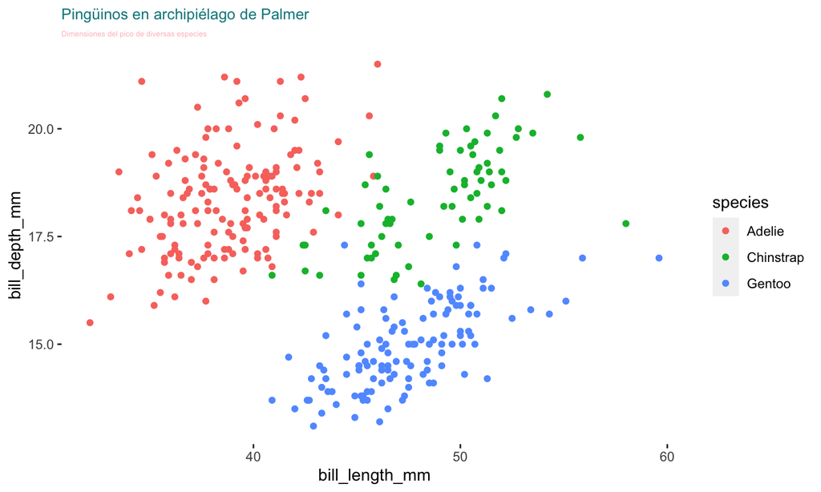

El código realizado anteriormente, lo guardaremos con el nombre que estimes conveniente. Luego, aplicaremos esos cambios a los gráficos con el operador “+”.

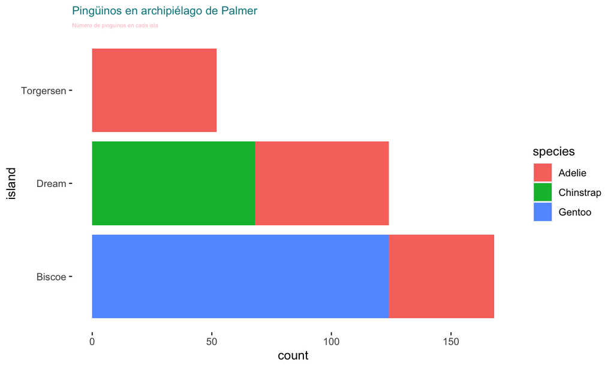

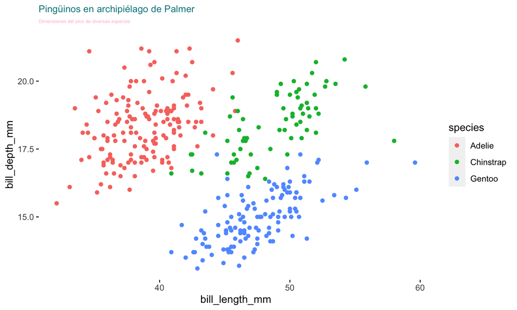